# Time scales for cline flattening

Fri Feb 26 23:08:42 2016

Here we would like to explore what happens over various time scales. We'll do:

- tens of generations
- hundreds of generations
- thousands of generations

# Tens of generations

First, the setup:

```r
s <- 0.1
tt <- seq(0,40,length.out=21)
xgrid <- setup.grid.1D(x.up=-20.5, x.down=20.5, N=41)
rr <- seq(0,0.2,length.out=21)
rcols <- rainbow(length(rr)*1.2)[seq_along(rr)]
fwds.soln <- forwards_pde(s=s,times=tt,grid=extend_grid(xgrid))
pfun <- cline_fun(fwds.soln)
```

We'll solve it up until time 40 and on a grid of 41 sites from -20 to 20.

Here's the behaviour of the selected site that we use to describe the behaviour of the other sites:

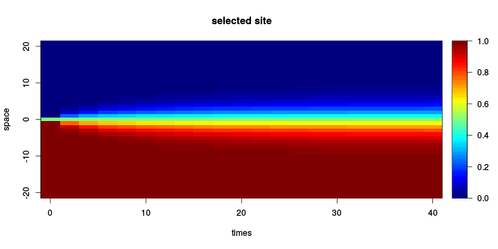

```r
image(fwds.soln, legend=TRUE, zlim=c(0,1), yaxt='n', main="selected site", ylab="space")
add_grid_axis(attr(fwds.soln,"grid"))
```

## Linked clines

```r
linked.solns <- lapply( rr, function (r) {
            forwards_backwards_pde(s=s,times=tt,grid=xgrid,r=r,log.p=TRUE,fwds.soln=fwds.soln)
        } )
linked.clines <- lapply( linked.solns, cline_from_soln, grid=xgrid )
```

Here are linked clines for a few time steps:

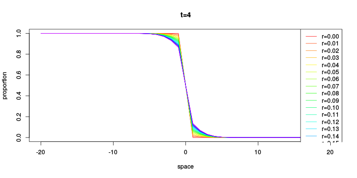

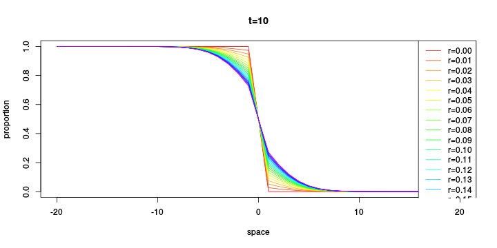

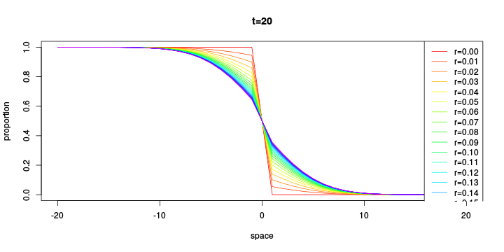

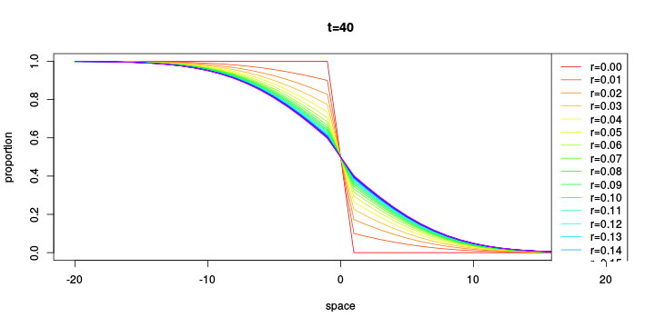

```r
for (plot.t in c(4,10,20,40)) {
    k <- which.min(abs(tt-plot.t))
    lclines <- sapply( linked.clines, cline_interp, t=tt[k] )
    matplot( xgrid$x.mid, lclines, type='l', ylab="proportion", xlab='space',
            main=sprintf("t=%0.0f",tt[k]),
           lty=1, col=rcols )
    legend("topright", lty=1, col=rcols, legend=sprintf("r=%0.2f",rr) )
}
```

## Ancestry disequilibrium

Now we'll look at ancestry disequilibrium across the region.

```r
rr <- seq(-0.2,0.2,length.out=21)
rcols <- rainbow(length(unique(abs(rr)))*1.2)[match(abs(rr),unique(abs(rr)))]
rpairs <- as.matrix(subset(expand.grid(r1=rr,r2=rr),r1<r2))
AD.solns <- parallel::mclapply( 1:nrow(rpairs), function (k)
               forwards_backwards_haplotypes(s=s, times=tt, xgrid=xgrid, rgrid=list(x.mid=rpairs[k,],N=2), fwds.soln=fwds.soln),
           mc.cores=parallel::detectCores() )
AD.values <- lapply( AD.solns, AD_from_soln, xgrid=xgrid )
```

Here are heatmaps of ancestry LD at a few different times and locations The selected site is in the center.

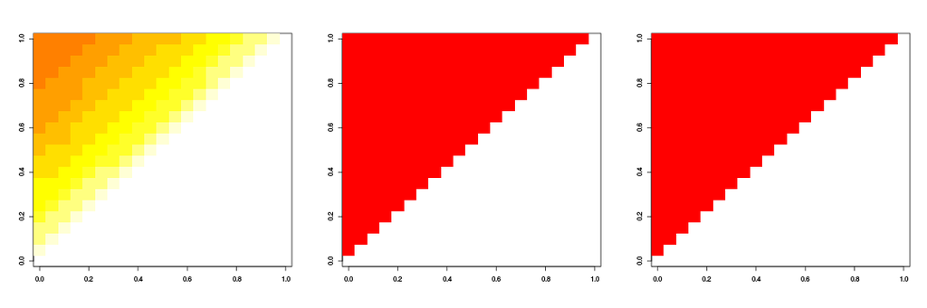

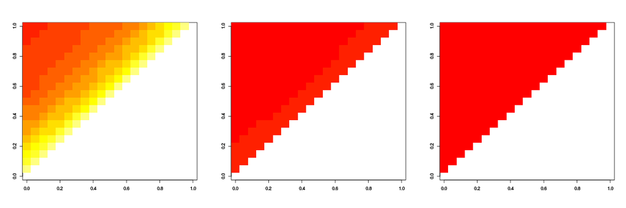

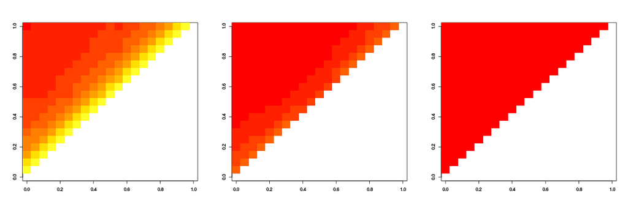

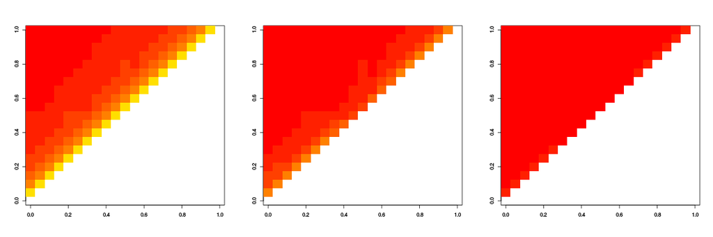

```r
plot.x <- c(0,5,10)
layout(t(1:3))
for (plot.t in c(4,10,20,40)) {
    for (k in seq_along(plot.x)) {
        this.t <- match(plot.t,tt)
        this.x <- match(plot.x[k],xgrid$x.mid)
        ADmat <- matrix(NA,nrow=length(rr),ncol=length(rr))
        ADmat[cbind(match(rpairs[,1],rr),match(rpairs[,2],rr))] <- sapply( AD.values, "[", cbind(this.t,this.x) )
        image(ADmat,zlim=c(0,max(unlist(AD.values))))
    }
}
```

# Hundreds of generations

First, the setup:

```r
s <- 0.1
tt <- seq(0,400,length.out=21)
xgrid <- setup.grid.1D(x.up=-20.5, x.down=20.5, N=41)
rr <- seq(0,0.2,length.out=21)
rcols <- rainbow(length(rr)*1.2)[seq_along(rr)]
fwds.soln <- forwards_pde(s=s,times=tt,grid=extend_grid(xgrid))
pfun <- cline_fun(fwds.soln)
```

We'll solve it up until time 400 and on a grid of 41 sites from -20 to 20.

Here's the behaviour of the selected site that we use to describe the behaviour of the other sites:

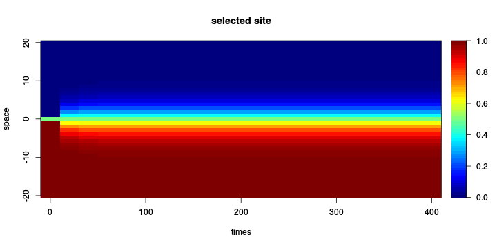

```r
image(fwds.soln, legend=TRUE, zlim=c(0,1), yaxt='n', main="selected site", ylab="space")
add_grid_axis(xgrid)
```

## Linked clines

```r
linked.solns <- lapply( rr, function (r) {
            forwards_backwards_pde(s=s,times=tt,grid=xgrid,r=r,log.p=TRUE,fwds.soln=fwds.soln)
        } )
linked.clines <- lapply( linked.solns, cline_from_soln, grid=xgrid )
```

Here are linked clines for a few time steps:

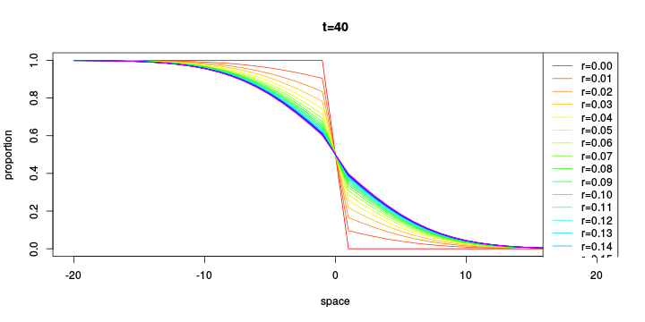

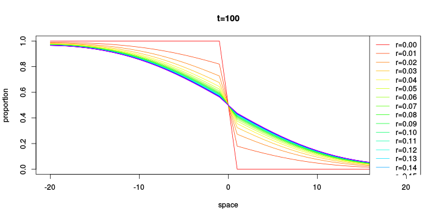

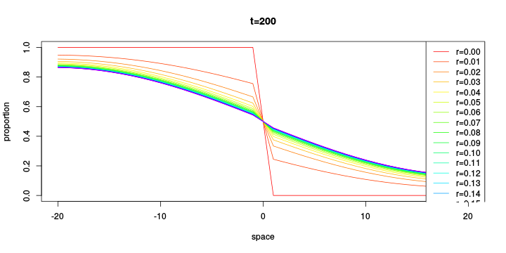

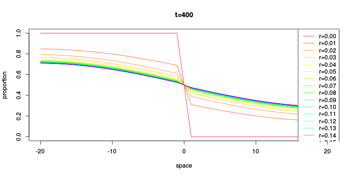

```r
for (plot.t in 10*c(4,10,20,40)) {
    k <- which.min(abs(tt-plot.t))
    lclines <- sapply( linked.clines, cline_interp, t=tt[k] )
    matplot( xgrid$x.mid, lclines, type='l', ylab="proportion", xlab='space',
            main=sprintf("t=%0.0f",tt[k]),
           lty=1, col=rcols, ylim=c(0,1) )
    legend("topright", lty=1, col=rcols, legend=sprintf("r=%0.2f",rr) )
}
```

## Ancestry disequilibrium

Now we'll look at ancestry disequilibrium across the region.

```r
rr <- seq(-0.2,0.2,length.out=21)
rcols <- rainbow(length(unique(abs(rr)))*1.2)[match(abs(rr),unique(abs(rr)))]
rpairs <- as.matrix(subset(expand.grid(r1=rr,r2=rr),r1<r2))
AD.solns <- parallel::mclapply( 1:nrow(rpairs), function (k)
               forwards_backwards_haplotypes(s=s, times=tt, xgrid=xgrid, rgrid=list(x.mid=rpairs[k,],N=2), fwds.soln=fwds.soln),
           mc.cores=parallel::detectCores() )
AD.values <- lapply( AD.solns, AD_from_soln, xgrid=xgrid )
```

Here are heatmaps of ancestry LD at a few different times and locations The selected site is in the center.

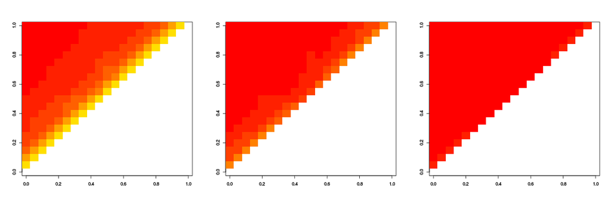

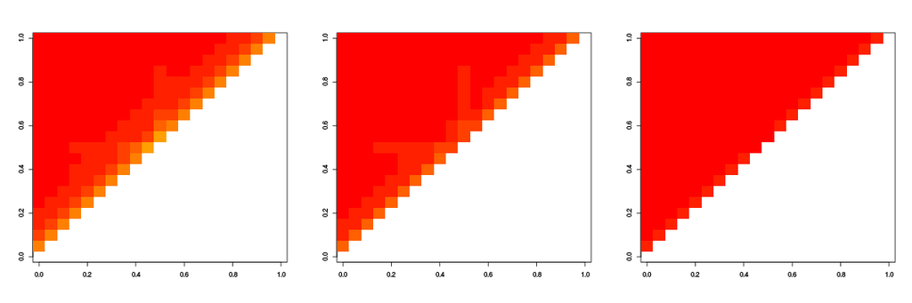

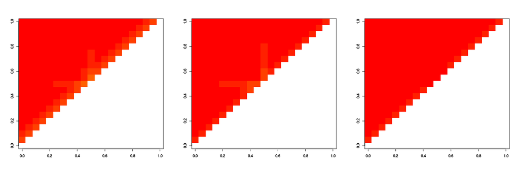

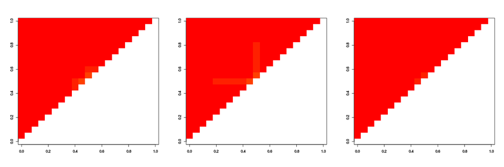

```r
plot.x <- c(0,5,10)
layout(t(1:3))
for (plot.t in 10*c(4,10,20,40)) {
    for (k in seq_along(plot.x)) {
        this.t <- match(plot.t,tt)
        this.x <- match(plot.x[k],xgrid$x.mid)
        ADmat <- matrix(NA,nrow=length(rr),ncol=length(rr))
        ADmat[cbind(match(rpairs[,1],rr),match(rpairs[,2],rr))] <- sapply( AD.values, "[", cbind(this.t,this.x) )
        image(ADmat,zlim=c(0,max(unlist(AD.values))))
    }
}
```

# Thousands of generations

First, the setup:

```r
s <- 0.1
tt <- seq(0,4000,length.out=21)
xgrid <- setup.grid.1D(x.up=-20.5, x.down=20.5, N=41)
rr <- seq(0,0.2,length.out=21)
rcols <- rainbow(length(rr)*1.2)[seq_along(rr)]
fwds.soln <- forwards_pde(s=s,times=tt,grid=extend_grid(xgrid))
pfun <- cline_fun(fwds.soln)
```

We'll solve it up until time 4000 and on a grid of 41 sites from -20 to 20.

Here's the behaviour of the selected site that we use to describe the behaviour of the other sites:

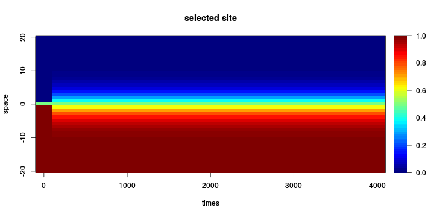

```r
image(fwds.soln, legend=TRUE, zlim=c(0,1), yaxt='n', main="selected site", ylab="space")
add_grid_axis(xgrid)
```

## Linked clines

```r
linked.solns <- lapply( rr, function (r) {
            forwards_backwards_pde(s=s,times=tt,grid=xgrid,r=r,log.p=TRUE,fwds.soln=fwds.soln)
        } )
linked.clines <- lapply( linked.solns, cline_from_soln, grid=xgrid )
```

Here are linked clines for a few time steps:

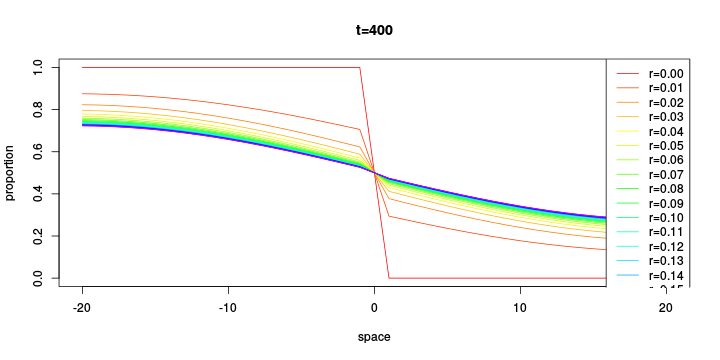

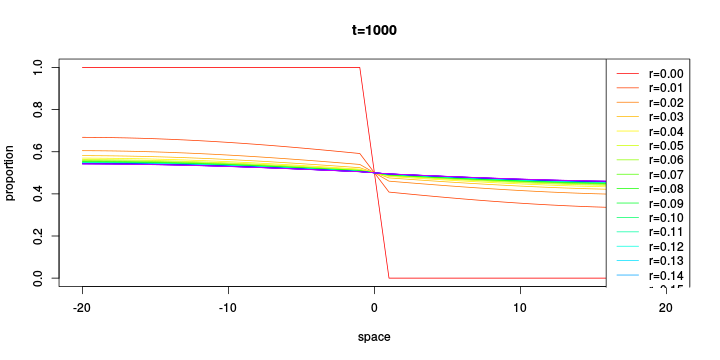

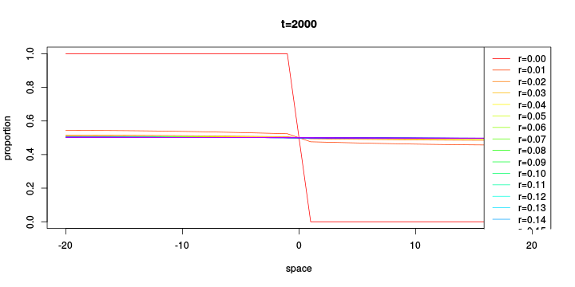

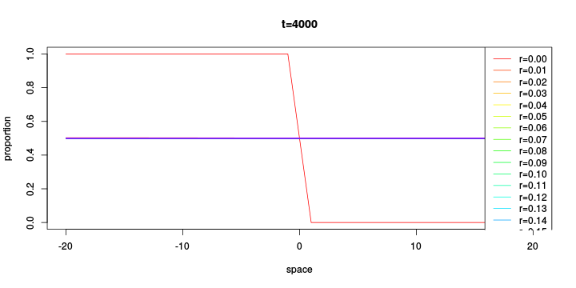

```r
for (plot.t in 100*c(4,10,20,40)) {
    k <- which.min(abs(tt-plot.t))
    lclines <- sapply( linked.clines, cline_interp, t=tt[k] )
    matplot( xgrid$x.mid, lclines, type='l', ylab="proportion", xlab='space',
            main=sprintf("t=%0.0f",tt[k]),
           lty=1, col=rcols )
    legend("topright", lty=1, col=rcols, legend=sprintf("r=%0.2f",rr) )
}
```

## Ancestry disequilibrium

Now we'll look at ancestry disequilibrium across the region.

```r
rr <- seq(-0.2,0.2,length.out=21)
rcols <- rainbow(length(unique(abs(rr)))*1.2)[match(abs(rr),unique(abs(rr)))]
rpairs <- as.matrix(subset(expand.grid(r1=rr,r2=rr),r1<r2))
AD.solns <- parallel::mclapply( 1:nrow(rpairs), function (k)
               forwards_backwards_haplotypes(s=s, times=tt, xgrid=xgrid, rgrid=list(x.mid=rpairs[k,],N=2), fwds.soln=fwds.soln),
           mc.cores=parallel::detectCores() )
AD.values <- lapply( AD.solns, AD_from_soln, xgrid=xgrid )
```

Here are heatmaps of ancestry LD at a few different times and locations The selected site is in the center.

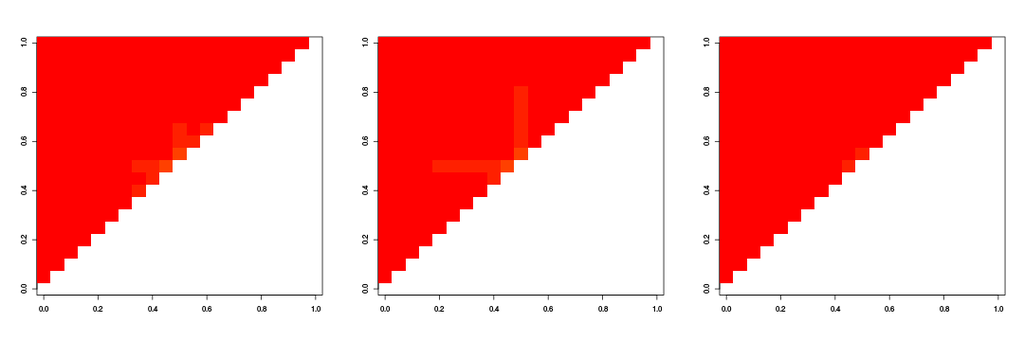

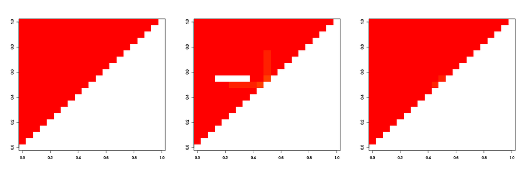

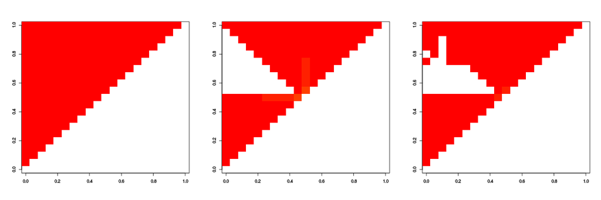

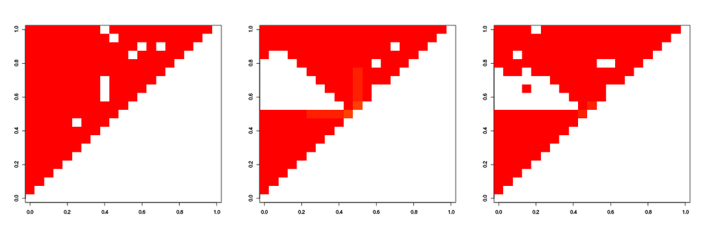

```r
plot.x <- c(0,5,10)
layout(t(1:3))
for (plot.t in 100*c(4,10,20,40)) {
    for (k in seq_along(plot.x)) {
        this.t <- match(plot.t,tt)
        this.x <- match(plot.x[k],xgrid$x.mid)
        ADmat <- matrix(NA,nrow=length(rr),ncol=length(rr))
        ADmat[cbind(match(rpairs[,1],rr),match(rpairs[,2],rr))] <- sapply( AD.values, "[", cbind(this.t,this.x) )
        image(ADmat,zlim=c(0,max(unlist(AD.values))))
    }
}
```